# NBA_2

Matias Corredoira

7/11/2020

## Cargamos las librerías consideradas necesarias

En primer lugar cargamos las librerías que nos harán falta para las operaciones pertinentes

```r
library(here)                                                                   # Comentarios
library(rsample)                                                                # data splitting
library(dplyr)
library(glmnet)                                                                 # implementing regularized regression approaches
library(tidyverse)
library(magrittr)                                                               # Pipe operators %<>%
library(janitor)                                                                # Limpieza de nombres
```

Cargamos la base de datos

```r
nba = read.csv("nba.csv")
View(nba)
```

## Limpieza de datos

Marcamos bien los nombres para trabajarlos mejor y pedimos los nuevos resultados

```r
nba %<>% clean_names()   #Ya que con los anteriores es posible que nos surgieran problemas


colnames(nba)            #Vemos todas y cada una
```

```
##  [1] "player"           "salary"           "nba_country"      "nba_draft_number"
##  [5] "age"              "tm"               "g"                "mp"
##  [9] "per"              "ts"               "x3p_ar"           "f_tr"
## [13] "orb"              "drb"              "trb"              "ast"
## [17] "stl"              "blk"              "tov"              "usg"
## [21] "ows"              "dws"              "ws"               "ws_48"
## [25] "obpm"             "dbpm"             "bpm"              "vorp"
```

Existen algunos valores duplicados dentro de los jugadores por lo que pedimos la seleccion individual.

```r
nba %<>% distinct(player, .keep_all = T)
```

Calculamos la cantidad de valores nan dentro de la base de datos Existen, pero son muy pocos, por lo que optamos por borrarlos ya que su cancelacion consideramos que no alteraría los datos de forma significativa.

```r
summarise_all(nba, funs(sum(is.na(.))))
```

```
##   player salary nba_country nba_draft_number age tm g mp per ts x3p_ar f_tr orb
## 1      0      0           0                0   0  0 0  0   0  2      2    2   0
##   drb trb ast stl blk tov usg ows dws ws ws_48 obpm dbpm bpm vorp
## 1   0   0   0   0   0   2   0   0   0  0     0    0    0   0    0
```

Los borramos con drop_na()

```r
nba %<>% drop_na()
```

Comprobamos que ya no están

```r
summarise_all(nba, funs(sum(is.na(.))))
```

```
##   player salary nba_country nba_draft_number age tm g mp per ts x3p_ar f_tr orb
## 1      0      0           0                0   0  0 0  0   0  0      0    0   0
##   drb trb ast stl blk tov usg ows dws ws ws_48 obpm dbpm bpm vorp
## 1   0   0   0   0   0   0   0   0   0  0     0    0    0   0    0
```

Creamos un vector con las variables factor para no incluirlas en los momentos que nos parezca pertinente

```r
vars_cats <- c('player', 'nba_country', 'tm')

log_nba <- log_nba %>%
  select_at(vars(-vars_cats))
```

```
## Note: Using an external vector in selections is ambiguous.
## i Use `all_of(vars_cats)` instead of `vars_cats` to silence this message.
## i See <https://tidyselect.r-lib.org/reference/faq-external-vector.html>.
```

# Elastic Net

Creamos una semilla para generar los números aleatorios que consideremos apropiados - Dividimos la base de datos en 2 partes para poder realizar su predicción. Concederemos el 80% de los datos a train y el 20 al test

```r
set.seed(3131)

nba_split <- initial_split(log_nba, prop = 0.80, strata ="salary")
nba_train <- training (nba_split)
nba_test  <- testing (nba_split)
```

Ajustamos

```r
nba_train_x <- model.matrix(salary ~ ., nba_train)[, -1]
nba_train_y <- log(nba_train$salary)

nba_test_x <- model.matrix(salary~ ., nba_test)[, -1]
nba_test_y <- log(nba_test$salary)

# comprobacion de que el training esta bien ( siempre mayor que el test)
dim(nba_train_x)
```

```
## [1] 388  24
```

Realizamos una representació gráfica para cada uno de los 4

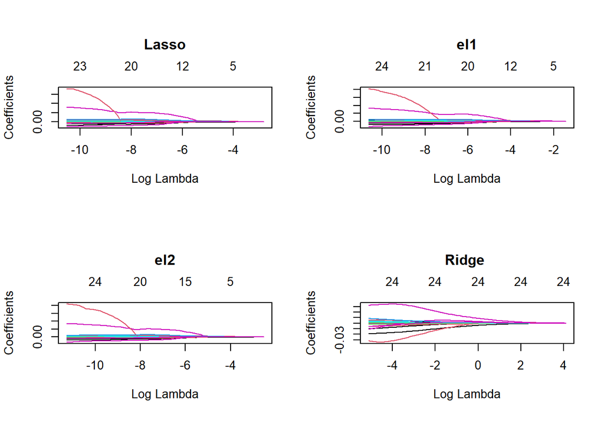

```r
par(mfrow = c(2, 2), mar = c(6, 4, 6, 2) + 0.1)
plot(lasso, xvar = "lambda", main = "Lasso")
plot(el1, xvar = "lambda", main = "el1")
plot(el2, xvar = "lambda", main = "el2")
plot(ridge, xvar = "lambda", main = "Ridge ")
```

# Tunning

En primer lugar mantenemos la misma cantidad de fold. De entre los distintos valores de alfa cada 0.1 busca

```r
fold_id <- sample(1:10, size = length(nba_train_y), replace=TRUE)

# De entre los distintos valores de alfa cada 0.1 busca
tuning_grid <- tibble::tibble(
alpha = seq(0, 1, by = .1),
mse_min = NA,
mse_1se = NA,
lambda_min = NA,
lambda_1se = NA
)
tuning_grid
```

```
## # A tibble: 11 x 5
##    alpha mse_min mse_1se lambda_min lambda_1se
##    <dbl> <lgl>   <lgl>   <lgl>      <lgl>
##  1   0   NA      NA      NA         NA
##  2   0.1 NA      NA      NA         NA
##  3   0.2 NA      NA      NA         NA
##  4   0.3 NA      NA      NA         NA
##  5   0.4 NA      NA      NA         NA
##  6   0.5 NA      NA      NA         NA
##  7   0.6 NA      NA      NA         NA
##  8   0.7 NA      NA      NA         NA
##  9   0.8 NA      NA      NA         NA
## 10   0.9 NA      NA      NA         NA
## 11   1   NA      NA      NA         NA
```

A continuación se justa el modelo de CV para cada valor alfa. Extracción tanto de MSE como de lambda

```r
# completamos la tabla:

for(i in seq_along(tuning_grid$alpha)) {

# aValor para cada valor alfa
fit <- cv.glmnet(nba_train_x, nba_train_y, alpha = tuning_grid$alpha[i], foldid = fold_id)

# Extraemos mse y valores alpha
tuning_grid$mse_min[i] <- fit$cvm[fit$lambda == fit$lambda.min]
tuning_grid$mse_1se[i] <- fit$cvm[fit$lambda == fit$lambda.1se]
tuning_grid$lambda_min[i] <- fit$lambda.min
tuning_grid$lambda_1se[i] <- fit$lambda.1se
}

tuning_grid
```

```
## # A tibble: 11 x 5
##    alpha mse_min mse_1se lambda_min lambda_1se
##    <dbl>   <dbl>   <dbl>      <dbl>      <dbl>
##  1   0   0.00588 0.00640   0.0105       0.0812
##  2   0.1 0.00584 0.00639   0.00433      0.0586
##  3   0.2 0.00583 0.00635   0.00314      0.0425
##  4   0.3 0.00582 0.00636   0.00230      0.0342
##  5   0.4 0.00582 0.00635   0.00189      0.0281
##  6   0.5 0.00581 0.00629   0.00166      0.0225
##  7   0.6 0.00580 0.00633   0.00139      0.0206
##  8   0.7 0.00580 0.00629   0.00130      0.0176
##  9   0.8 0.00579 0.00625   0.00114      0.0154
## 10   0.9 0.00579 0.00631   0.00101      0.0151
## 11   1   0.00579 0.00628   0.000912     0.0135
```

Representamos graficamente la relación entre ambas

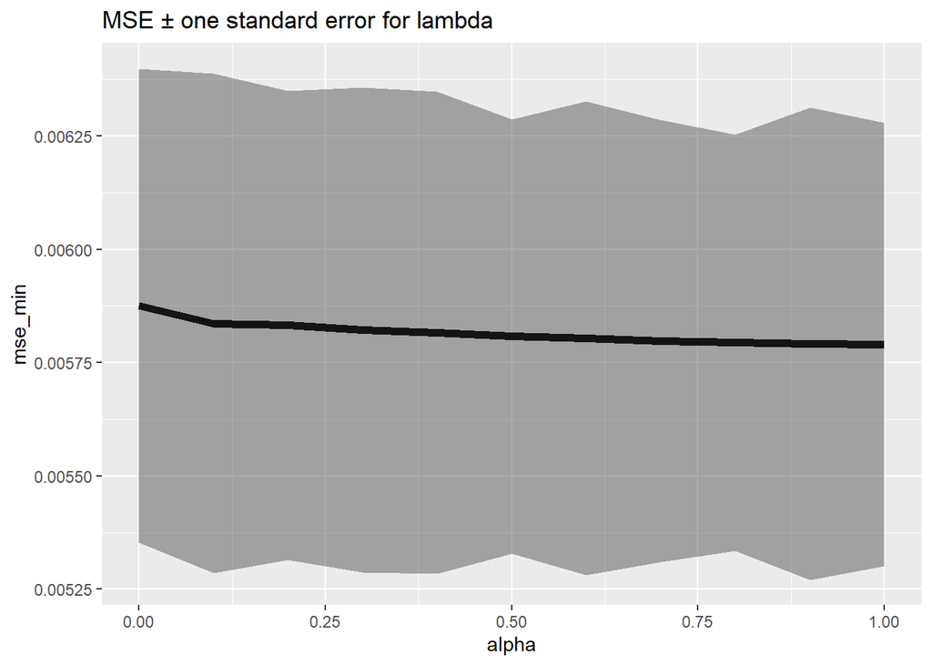

```r
tuning_grid %>%
  mutate(se = mse_1se - mse_min) %>%
  ggplot(aes(alpha, mse_min)) +
  geom_line(size = 2) +
  geom_ribbon(aes(ymax = mse_min + se, ymin = mse_min - se), alpha = .4) +
  ggtitle("MSE ± one standard error for lambda")
```

El valor alpha que minimiza el MSE en el rango pautado anteriormente nos indica que el mejor valor para minimizar MSE es 1.

## Predicciones

Calculamos el mejor modelo

En este caso con Lsso

```r
cv_lasso <- cv.glmnet(nba_train_x, nba_train_y, alpha = 1)
min(cv_lasso$cvm)
```

```
## [1] 0.006289897
```

Realizamos la comparación con los datos reales.

```r
pred <- predict(cv_lasso, s = cv_lasso$lambda.min, nba_test_x)
mean((nba_test_y - pred)^2)
```

```
## [1] 0.005546257
```

Modelo con un alpha de 0.4

```r
cv_net   <- cv.glmnet(nba_train_x, nba_train_y, alpha = 0.4)
min(cv_net$cvm)
```

```
## [1] 0.005971466
```

```r
pred <- predict(cv_net, s = cv_net$lambda.min, nba_test_x)
mean((nba_test_y - pred)^2)
```

```
## [1] 0.006094246
```

Como conclusión extraemos que la mejor predicción es la de Lasso dado que es el que nos proporciona un error más bajo respecto a los valores reales.